# Stock price direction prediction

## Absract

For this project, we decided to work on the prediction of future stock price using custom built Keras densely-connected Neural Network models and long short-term memory (LSTM) models. We present our data's source and libraries to retrieve the data. We clean our data and apply some preprocessing on it. We mention the possible hyper-parameters that can be used in our case, and tweak them in order to find the best hyper-parameters for this task. Finally, we create a multi-input model where inputs are different size sequences of price data.

```python
# Necessary dependencies
!pip install yfinance
!pip install finvizfinance
```

```python
import numpy as np
from tensorflow.keras import *
import yfinance as yf
from finvizfinance.screener.overview import Overview
import matplotlib.pyplot as pl
```

### API Docs

"yfinance" library is used to download historical data

- https://pypi.org/project/yfinance/

"finvizfinance" library is used to get ticker names

- https://pypi.org/project/finvizfinance/

## Get Data

```python
# Get an overview of the screener
overview = Overview()
```

```python
# Here are the options for filters to use to filter stocks
overview.getFilters()
```

```
['Exchange',
 'Index',
 'Sector',
 'Industry',
 'Country',
 'Market Cap.',
 'P/E',
 'Forward P/E',
 'PEG',
 'P/S',
 'P/B',
 'Price/Cash',
 'Price/Free Cash Flow',
 'EPS growththis year',
 'EPS growthnext year',
 'EPS growthpast 5 years',
 'EPS growthnext 5 years',
 'Sales growthpast 5 years',
 'EPS growthqtr over qtr',
 'Sales growthqtr over qtr',
 'Dividend Yield',
 'Return on Assets',
 'Return on Equity',
 'Return on Investment',
 'Current Ratio',
 'Quick Ratio',
 'LT Debt/Equity',
 'Debt/Equity',
 'Gross Margin',
 'Operating Margin',
 'Net Profit Margin',
 'Payout Ratio',
 'InsiderOwnership',
 'InsiderTransactions',
 'InstitutionalOwnership',
 'InstitutionalTransactions',
 'Float Short',
 'Analyst Recom.',
 'Option/Short',
 'Earnings Date',
```

[output cut: 10 more lines]

```
 '20-Day High/Low',
 '50-Day High/Low',
 '52-Week High/Low',
 'Pattern',
 'Candlestick',
 'Beta',
 'Average True Range',
 'Average Volume',
 'Relative Volume',
 'Current Volume',
 'Price',
 'Target Price',
 'IPO Date',
 'Shares Outstanding',
 'Float']
```

```python
# We would like to retrieve stocks with the highest Market Capitalization.
# "Market capitalization refers to the total dollar market value of a company's outstanding shares of stock."
# In other words, these are the most valued stocks. The reasoning behind selecting this filter is simply that
# these are strong stocks that are traded by most investors or hedge funds.
overview.getFilterOptions('Market Cap.')
```

```
['Any',
 'Mega ($200bln and more)',
 'Large ($10bln to $200bln)',
 'Mid ($2bln to $10bln)',
 'Small ($300mln to $2bln)',
 'Micro ($50mln to $300mln)',
 'Nano (under $50mln)',
 '+Large (over $10bln)',
 '+Mid (over $2bln)',
 '+Small (over $300mln)',
 '+Micro (over $50mln)',
 '-Large (under $200bln)',
 '-Mid (under $10bln)',
 '-Small (under $2bln)',
 '-Micro (under $300mln)']
```

```python
filters = {'Market Cap.':'+Large (over $10bln)'}
overview.set_filter(filters_dict=filters)
df = overview.ScreenerView()
```

```python
df
```

|  | Ticker | Company | Sector | Industry | Country | Market Cap | P/E | Price | Change | Volume |
| --- | --- | --- | --- | --- | --- | --- | --- | --- | --- | --- |
| 0 | A | Agilent Technologies, Inc. | Healthcare | Diagnostics & Research | USA | 3.982000e+10 | 50.64 | 131.91 | 0.0093 | 1544869.0 |
| 1 | AAL | American Airlines Group Inc. | Industrials | Airlines | USA | 1.517000e+10 | None | 23.54 | -0.0047 | 21205992.0 |
| 2 | AAP | Advance Auto Parts, Inc. | Consumer Cyclical | Specialty Retail | USA | 1.181000e+10 | 25.75 | 183.97 | 0.0192 | 828884.0 |
| 3 | AAPL | Apple Inc. | Technology | Consumer Electronics | USA | 2.188500e+12 | 35.95 | 132.99 | 0.0202 | 105373037.0 |
| 4 | ABB | ABB Ltd | Industrials | Specialty Industrial Machinery | Switzerland | 6.805000e+10 | 234.16 | 32.08 | 0.0158 | 978155.0 |
| ... | ... | ... | ... | ... | ... | ... | ... | ... | ... | ... |
| 869 | ZNGA | Zynga Inc. | Communication Services | Electronic Gaming & Multimedia | USA | 1.159000e+10 | None | 10.61 | -0.0066 | 11275493.0 |
| 870 | ZNH | China Southern Airlines Company Limited | Industrials | Airlines | China | 1.511000e+10 | None | 36.55 | -0.0214 | 26219.0 |
| 871 | ZS | Zscaler, Inc. | Technology | Software - Infrastructure | USA | 2.517000e+10 | None | 185.04 | -0.0008 | 1121549.0 |
| 872 | ZTO | ZTO Express (Cayman) Inc. | Industrials | Integrated Freight & Logistics | China | 2.426000e+10 | 34.18 | 28.20 | -0.0060 | 3656268.0 |
| 873 | ZTS | Zoetis Inc. | Healthcare | Drug Manufacturers - Specialty & Generic | USA | 7.600000e+10 | 46.7 | 159.85 | -0.0009 | 1820024.0 |

874 rows × 10 columns

```python
tickers = df['Ticker'].values.tolist()
```

```python
# Now that we have the tickers, we can download historical data for these tickers.
# We will download daily data from 2019 to 2021 (2 years).
data = yf.download(tickers, start='2019-01-02', end='2021-01-02')
```

```
[*********************100%***********************]  874 of 874 completed

9 Failed downloads:
- FOX: No data found for this date range, symbol may be delisted
- RLX: Data doesn't exist for startDate = 1546387200, endDate = 1609545600
- RBLX: Data doesn't exist for startDate = 1546387200, endDate = 1609545600
- XM: Data doesn't exist for startDate = 1546387200, endDate = 1609545600
- PLTK: Data doesn't exist for startDate = 1546387200, endDate = 1609545600
- TUYA: Data doesn't exist for startDate = 1546387200, endDate = 1609545600
- AFRM: Data doesn't exist for startDate = 1546387200, endDate = 1609545600
- PSFE: No data found for this date range, symbol may be delisted
- CPNG: Data doesn't exist for startDate = 1546387200, endDate = 1609545600
```

```python
data
```

| Date | Adj Close A | Adj Close AAL | Adj Close AAP | Adj Close AAPL | Adj Close ABB | Adj Close ABBV | Adj Close ABC | Adj Close ABEV | Adj Close ABMD | Adj Close ABNB | Adj Close ABT | Adj Close ACGL | Adj Close ACN | Adj Close ADBE | Adj Close ADI | Adj Close ADM | Adj Close ADP | Adj Close ADSK | Adj Close AEE | Adj Close AEG | Adj Close AEM | Adj Close AEP | Adj Close AES | Adj Close AFL | Adj Close AFRM | Adj Close AGCO | Adj Close AGR | Adj Close AIG | Adj Close AJG | … |
| --- | --- | --- | --- | --- | --- | --- | --- | --- | --- | --- | --- | --- | --- | --- | --- | --- | --- | --- | --- | --- | --- | --- | --- | --- | --- | --- | --- | --- | --- | --- |
| 2019-01-02 | 64.511734 | 31.963160 | 156.258942 | 38.505024 | 16.999094 | 77.952286 | 71.464157 | 3.967193 | 309.959991 | NaN | 67.034943 | 26.190001 | 136.179626 | 224.570007 | 82.134567 | 38.000431 | 123.853729 | 128.960007 | 60.357964 | 3.857965 | 39.101059 | 67.802513 | 13.184999 | 43.072632 | NaN | 54.434406 | 44.871288 | 36.799793 | 69.031372 | … |
| 2019-01-03 | 62.135132 | 29.581665 | 161.137100 | 34.669640 | 16.659115 | 75.383873 | 70.427460 | 4.004976 | 302.290009 | NaN | 63.871284 | 25.780001 | 131.530212 | 215.699997 | 77.173225 | 37.833397 | 120.113564 | 121.849998 | 60.509964 | 3.849596 | 39.972771 | 67.644478 | 13.175699 | 41.984459 | NaN | 53.268085 | 44.733059 | 35.991718 | 67.735062 | … |
| 2019-01-04 | 64.285828 | 31.530161 | 157.139572 | 36.149662 | 17.258556 | 77.812500 | 71.243378 | 4.174999 | 313.440002 | NaN | 65.694260 | 26.389999 | 136.644577 | 226.190002 | 79.046875 | 38.705696 | 124.900612 | 128.279999 | 61.365028 | 4.025339 | 39.217285 | 68.267288 | 13.612720 | 42.504887 | NaN | 56.404396 | 45.368942 | 37.319923 | 69.444275 | … |
| 2019-01-07 | 65.650917 | 32.425678 | 159.445038 | 36.069202 | 17.195925 | 78.948189 | 71.752113 | 4.108879 | 314.799988 | NaN | 66.678070 | 26.330000 | 137.119217 | 229.259995 | 79.543961 | 38.900562 | 124.224884 | 132.720001 | 60.661980 | 4.092288 | 38.548969 | 67.886169 | 13.677810 | 42.731987 | NaN | 58.295975 | 44.613255 | 37.533558 | 69.242630 | … |
| 2019-01-08 | 66.613335 | 31.904110 | 158.336838 | 36.756794 | 17.446438 | 79.315125 | 72.520035 | 4.089987 | 318.420013 | NaN | 65.877518 | 26.430000 | 140.586914 | 232.679993 | 81.484528 | 39.624386 | 124.957687 | 133.869995 | 61.621552 | 4.092288 | 38.374630 | 68.722786 | 13.993949 | 42.864464 | NaN | 58.982044 | 45.387375 | 37.682171 | 69.549904 | … |
| ... | ... | ... | ... | ... | ... | ... | ... | ... | ... | ... | ... | ... | ... | ... | ... | ... | ... | ... | ... | ... | ... | ... | ... | ... | ... | ... | ... | ... | ... | … |
| 2020-12-24 | 116.939987 | 15.660000 | 160.459229 | 131.773087 | 26.885008 | 102.066246 | 96.568512 | 3.035146 | 303.410004 | 154.839996 | 107.915245 | 34.860001 | 256.423737 | 499.859985 | 143.853745 | 49.096794 | 175.658142 | 301.390015 | 76.470001 | 3.800000 | 71.063881 | 80.675980 | 23.116962 | 43.531662 | NaN | 103.073425 | 44.450527 | 37.123131 | 122.934410 | … |
| 2020-12-28 | 117.458351 | 16.059999 | 158.581818 | 136.486053 | 27.089199 | 102.254044 | 96.399216 | 3.015244 | 312.910004 | 149.000000 | 107.357498 | 35.330002 | 258.795624 | 498.950012 | 144.062851 | 49.354992 | 175.707886 | 299.649994 | 76.750000 | 3.890000 | 70.318352 | 80.537262 | 23.146763 | 43.611099 | NaN | 102.044785 | 45.015072 | 36.825111 | 122.545944 | … |
| 2020-12-29 | 116.860245 | 15.860000 | 156.474716 | 134.668762 | 27.118366 | 103.489594 | 96.717888 | 3.104805 | 320.929993 | 150.000000 | 107.895332 | 35.299999 | 256.882202 | 502.109985 | 143.047211 | 49.106728 | 173.976776 | 298.109985 | 76.570000 | 3.890000 | 70.755737 | 80.438171 | 23.156698 | 43.442295 | NaN | 101.126007 | 44.638706 | 36.914516 | 121.051849 | … |
| 2020-12-30 | 117.019737 | 16.150000 | 157.443390 | 133.520477 | 27.157261 | 104.053001 | 96.558548 | 3.035146 | 323.920013 | 148.429993 | 108.004890 | 35.580002 | 256.662933 | 497.450012 | 145.556442 | 49.563530 | 172.922180 | 299.410004 | 76.970001 | 3.920000 | 71.700066 | 80.765160 | 22.630184 | 43.700466 | NaN | 102.044785 | 45.054688 | 37.272141 | 121.221176 | … |
| 2020-12-31 | 118.116264 | 15.770000 | 157.293579 | 132.492020 | 27.186430 | 105.911278 | 97.355240 | 3.045097 | 324.200012 | 146.800003 | 109.050674 | 36.070000 | 260.320435 | 500.119995 | 147.099838 | 50.060062 | 175.299973 | 305.339996 | 78.059998 | 3.950000 | 70.089729 | 82.509071 | 23.345449 | 44.157234 | NaN | 102.953583 | 45.015072 | 37.609894 | 123.223267 | … |

506 rows × 5244 columns

```python
# The data contains multiple columns for each ticker including: open, close, low, and high price data.
# We will only need one of them.
data = data['Close']
data.shape
```

```
(506, 874)
```

## Preprocessing

```python
# First, we see that data for some tickers at some time is unavaiable/missing ('NaN').
# To keep the price data in its original form it is best to not replace the unavailable data with zeros or averages.
# Additionally, to preserve the size of the data for each ticker, we decided to remove tickers that contain unavailable data.
data.dropna(axis=1)
```

| Date |
| --- |
| 2019-01-02 |
| 2019-01-03 |
| 2019-01-04 |
| 2019-01-07 |
| 2019-01-08 |
| ... |
| 2020-12-24 |
| 2020-12-28 |
| 2020-12-29 |
| 2020-12-30 |
| 2020-12-31 |

506 rows × 0 columns

```python
# We find that all tickers contain at least one 'NaN' value. Thus, we experiment by setting a treshold.
# And we find that most tickers contain a single missing value. Thus, by setting the treshold to the row length - 1,
# we obtain an almost perfect data containing only one missing value.
data = data.dropna(axis=1, thresh=len(data)-1)
data.shape
```

```
(506, 808)
```

```python
# By removing rows that contain missing values, we discover that each ticker had a missing value row at the same index.
# Thus, now our data is 'NaN' value free and we preserved the most of our data without modifying values.
data = data.dropna(axis=0)
data.shape
```

```
(505, 808)
```

```python
# We must scale the data since different tickers have different prices
data -= data.min()
data /= data.max()
```

```python
data.head(5)
```

| Date | A | AAL | AAP | AAPL | ABB | ABBV | ABC | ABEV | ABMD | ABT | ACGL | ACN | ADBE | ADI | ADM | ADP | ADSK | AEE | AEG | AEM | AEP | AES | AFL | AGCO | AGR | AIG | AJG | AKAM | ALB | … |
| --- | --- | --- | --- | --- | --- | --- | --- | --- | --- | --- | --- | --- | --- | --- | --- | --- | --- | --- | --- | --- | --- | --- | --- | --- | --- | --- | --- | --- | --- | --- |
| 2019-01-02 | 0.043191 | 0.840445 | 0.779041 | 0.038881 | 0.316552 | 0.574524 | 0.086878 | 0.653179 | 0.774359 | 0.129457 | 0.152275 | 0.036793 | 0.027884 | 0.077463 | 0.515958 | 0.291909 | 0.038749 | 0.084047 | 0.780000 | 0.080024 | 0.085639 | 0.331420 | 0.640417 | 0.278494 | 0.614293 | 0.532856 | 0.060884 | 0.021173 | 0.274821 | … |
| 2019-01-03 | 0.000000 | 0.753675 | 0.825376 | 0.000000 | 0.287567 | 0.510177 | 0.059201 | 0.664740 | 0.741262 | 0.065892 | 0.136469 | 0.000000 | 0.000000 | 0.000000 | 0.507979 | 0.237462 | 0.000000 | 0.090272 | 0.777143 | 0.097984 | 0.080687 | 0.330703 | 0.604048 | 0.260648 | 0.606951 | 0.510611 | 0.038365 | 0.000000 | 0.220079 | … |
| 2019-01-04 | 0.039086 | 0.824668 | 0.787406 | 0.015004 | 0.338673 | 0.571022 | 0.080984 | 0.716763 | 0.789376 | 0.102519 | 0.159985 | 0.040472 | 0.032977 | 0.029254 | 0.549645 | 0.307149 | 0.035043 | 0.125292 | 0.837143 | 0.082419 | 0.100204 | 0.364419 | 0.621442 | 0.308638 | 0.640724 | 0.547175 | 0.068057 | 0.027154 | 0.255934 | … |
| 2019-01-07 | 0.063894 | 0.857297 | 0.809305 | 0.014188 | 0.333333 | 0.599475 | 0.094567 | 0.696532 | 0.795245 | 0.122287 | 0.157672 | 0.044228 | 0.042628 | 0.037015 | 0.558954 | 0.297312 | 0.059240 | 0.096498 | 0.860000 | 0.068649 | 0.088261 | 0.369440 | 0.629032 | 0.337582 | 0.600587 | 0.553055 | 0.064554 | 0.057217 | 0.259368 | … |
| 2019-01-08 | 0.081385 | 0.838293 | 0.798778 | 0.021158 | 0.354691 | 0.608667 | 0.115069 | 0.690751 | 0.810866 | 0.106202 | 0.161527 | 0.071670 | 0.053379 | 0.067313 | 0.593528 | 0.307980 | 0.065508 | 0.135798 | 0.860000 | 0.065057 | 0.114477 | 0.393831 | 0.633460 | 0.348080 | 0.641703 | 0.557147 | 0.069892 | 0.076774 | 0.266943 | … |

5 rows × 808 columns

### Setup

The idea behind our learning is to provide sequences of prices to a model and make the model predict the stock's future direction. We define this direction by the average of the 'n' future prices in contrast to the last price in the sequence.

We define parameters such as SEQ_LEN for the length of sequences that go into the model, and N_FUTURE for the number of future prices that we aggregate to compute the labels for the sequences.

```python
SEQ_LEN = 10        # Previous 10 days
N_FUTURE = 10       # Next 10 days
SPLIT = 0.2
```

```python
def processData(data, SEQ_LEN, N_FUTURE):
    train_data, test_data = [], []

    for ticker in data.columns:
        prices = data[ticker].values
        seqs = []

        for i in range(SEQ_LEN, len(prices)-N_FUTURE):
            seq = prices[i-SEQ_LEN:i]

            # Next, we want to compute the price direction from the current index
            future_price_avg = np.mean(prices[i:i+N_FUTURE])
            # direction is 0 (negative) if the future price average is below the current price, otherwise direction is 1 (positive)
            price_dir = 0 if future_price_avg < prices[i] else 1

            # Next, we append the direction as the label to the sequences
            # We include the price direction with the sequences so that we can shuffle the data while maintaining the labels corresponding
            # to the sequences.
            seqs.append([seq, price_dir])

        split_index = int(len(seqs) * (1 - SPLIT))
        train_data.extend(seqs[:split_index])
        # We ignore the overlap of sequences between the train data and the test data
        test_data.extend(seqs[split_index + SEQ_LEN:])

    # Shuffling
    np.random.seed(0)
    np.random.shuffle(train_data)
    np.random.shuffle(test_data)

    # Separating features and labels
    X_train = []
    y_train = []
    for features, label in train_data:
        X_train.append(features)
        y_train.append(label)
    X_train = np.array(X_train)
    y_train = np.array(y_train)

    X_test = []
    y_test = []
    for features, label in test_data:
        X_test.append(features)
        y_test.append(label)
    X_test = np.array(X_test)
    y_test = np.array(y_test)

    return (X_train, y_train), (X_test, y_test)
```

```python
(X_train, y_train), (X_test, y_test) = processData(data, SEQ_LEN, N_FUTURE)
```

## Model

### Linear model

```python
model1 = models.Sequential([
    layers.Input(shape=(SEQ_LEN,)),
    layers.Dense(128, activation='relu'),
    layers.Dense(128, activation='relu'),
    layers.Dense(64, activation='relu'),
    layers.Dense(64, activation='relu'),
    layers.Dense(32, activation='relu'),
    layers.Dense(1, activation='sigmoid')
])
model1.compile(optimizer='adam', loss='binary_crossentropy', metrics=['acc'])
model1.summary()
```

```
Model: "sequential"
_________________________________________________________________
Layer (type)                 Output Shape              Param #
=================================================================
dense (Dense)                (None, 128)               1408
_________________________________________________________________
dense_1 (Dense)              (None, 128)               16512
_________________________________________________________________
dense_2 (Dense)              (None, 64)                8256
_________________________________________________________________
dense_3 (Dense)              (None, 64)                4160
_________________________________________________________________
dense_4 (Dense)              (None, 32)                2080
_________________________________________________________________
dense_5 (Dense)              (None, 1)                 33
=================================================================
Total params: 32,449
Trainable params: 32,449
Non-trainable params: 0
_________________________________________________________________
```

```python
log1 = model1.fit(X_train, y_train, validation_data=(X_test, y_test), epochs=50, batch_size=128)
```

```
Best test acc: 0.5642284154891968
```

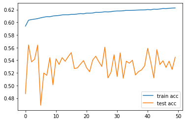

```python
pl.plot(log1.history['acc'])
pl.plot(log1.history['val_acc'])
pl.legend(['train acc', "test acc"])
print(f"Best test acc: {max(log1.history['val_acc'])}")
```

The model's training accuracy is slowly rising, but the test accuracy is not improving over epochs.

### LSTM model

```python
model2 = models.Sequential([
    layers.Input(shape=(SEQ_LEN,)),
    layers.Reshape((SEQ_LEN, 1)),
    layers.LSTM(64, return_sequences=True),
    layers.LSTM(64),
    layers.Dropout(0.2),
    layers.Dense(10, activation='relu'),
    layers.Dense(1, activation='sigmoid')
])
model2.compile(optimizer='adam', loss='binary_crossentropy', metrics=['acc'])
model2.summary()
```

```
Model: "sequential_1"
_________________________________________________________________
Layer (type)                 Output Shape              Param #
=================================================================
reshape (Reshape)            (None, 10, 1)             0
_________________________________________________________________
lstm (LSTM)                  (None, 10, 64)            16896
_________________________________________________________________
lstm_1 (LSTM)                (None, 64)                33024
_________________________________________________________________
dropout (Dropout)            (None, 64)                0
_________________________________________________________________
dense_6 (Dense)              (None, 10)                650
_________________________________________________________________
dense_7 (Dense)              (None, 1)                 11
=================================================================
Total params: 50,581
Trainable params: 50,581
Non-trainable params: 0
_________________________________________________________________
```

```python
log2 = model2.fit(X_train, y_train, validation_data=(X_test, y_test), epochs=50, batch_size=128)
```

```
Best test acc: 0.5699043869972229
```

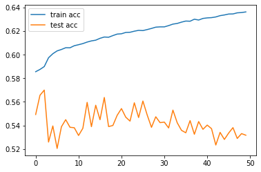

```python
pl.plot(log2.history['acc'])
pl.plot(log2.history['val_acc'])
pl.legend(['train acc', "test acc"])
print(f"Best test acc: {max(log2.history['val_acc'])}")
```

The same phenomenon happens with the LSTM model as with the linear model.

## Different parameters

```python
SEQ_LEN = 30
N_FUTURE = 10
(X_train, y_train), (X_test, y_test) = processData(data, SEQ_LEN, N_FUTURE)

model2 = models.Sequential([
    layers.Input(shape=(SEQ_LEN,)),
    layers.Reshape((SEQ_LEN, 1)),
    layers.LSTM(64, return_sequences=True),
    layers.LSTM(64),
    layers.Dropout(0.2),
    layers.Dense(10, activation='relu'),
    layers.Dense(1, activation='sigmoid')
])
model2.compile(optimizer='adam', loss='binary_crossentropy', metrics=['acc'])
log2_1 = model2.fit(X_train, y_train, validation_data=(X_test, y_test), epochs=50, batch_size=128)
```

```python
SEQ_LEN = 10
N_FUTURE = 30
(X_train, y_train), (X_test, y_test) = processData(data, SEQ_LEN, N_FUTURE)

model2 = models.Sequential([
    layers.Input(shape=(SEQ_LEN,)),
    layers.Reshape((SEQ_LEN, 1)),
    layers.LSTM(64, return_sequences=True),
    layers.LSTM(64),
    layers.Dropout(0.2),
    layers.Dense(10, activation='relu'),
    layers.Dense(1, activation='sigmoid')
])
model2.compile(optimizer='adam', loss='binary_crossentropy', metrics=['acc'])
log2_2 = model2.fit(X_train, y_train, validation_data=(X_test, y_test), epochs=50, batch_size=128)
```

```python
SEQ_LEN = 30
N_FUTURE = 30
(X_train, y_train), (X_test, y_test) = processData(data, SEQ_LEN, N_FUTURE)

model2 = models.Sequential([
    layers.Input(shape=(SEQ_LEN,)),
    layers.Reshape((SEQ_LEN, 1)),
    layers.LSTM(64, return_sequences=True),
    layers.LSTM(64),
    layers.Dropout(0.2),
    layers.Dense(10, activation='relu'),
    layers.Dense(1, activation='sigmoid')
])
model2.compile(optimizer='adam', loss='binary_crossentropy', metrics=['acc'])
log2_3 = model2.fit(X_train, y_train, validation_data=(X_test, y_test), epochs=50, batch_size=128)
```

```python
SEQ_LEN = 30
N_FUTURE = 60
(X_train, y_train), (X_test, y_test) = processData(data, SEQ_LEN, N_FUTURE)

model2 = models.Sequential([
    layers.Input(shape=(SEQ_LEN,)),
    layers.Reshape((SEQ_LEN, 1)),
    layers.LSTM(64, return_sequences=True),
    layers.LSTM(64),
    layers.Dropout(0.2),
    layers.Dense(10, activation='relu'),
    layers.Dense(1, activation='sigmoid')
])
model2.compile(optimizer='adam', loss='binary_crossentropy', metrics=['acc'])
log2_4 = model2.fit(X_train, y_train, validation_data=(X_test, y_test), epochs=50, batch_size=128)
```

```python
SEQ_LEN = 60
N_FUTURE = 30
(X_train, y_train), (X_test, y_test) = processData(data, SEQ_LEN, N_FUTURE)

model2 = models.Sequential([
    layers.Input(shape=(SEQ_LEN,)),
    layers.Reshape((SEQ_LEN, 1)),
    layers.LSTM(64, return_sequences=True),
    layers.LSTM(64),
    layers.Dropout(0.2),
    layers.Dense(10, activation='relu'),
    layers.Dense(1, activation='sigmoid')
])
model2.compile(optimizer='adam', loss='binary_crossentropy', metrics=['acc'])
log2_5 = model2.fit(X_train, y_train, validation_data=(X_test, y_test), epochs=50, batch_size=128)
```

```python
SEQ_LEN = 60
N_FUTURE = 60
(X_train, y_train), (X_test, y_test) = processData(data, SEQ_LEN, N_FUTURE)

model2 = models.Sequential([
    layers.Input(shape=(SEQ_LEN,)),
    layers.Reshape((SEQ_LEN, 1)),
    layers.LSTM(64, return_sequences=True),
    layers.LSTM(64),
    layers.Dropout(0.2),
    layers.Dense(10, activation='relu'),
    layers.Dense(1, activation='sigmoid')
])
model2.compile(optimizer='adam', loss='binary_crossentropy', metrics=['acc'])
log2_6 = model2.fit(X_train, y_train, validation_data=(X_test, y_test), epochs=50, batch_size=128)
```

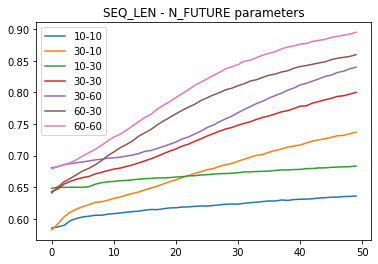

```python
pl.plot(log2.history['acc'])
pl.plot(log2_1.history['acc'])
pl.plot(log2_2.history['acc'])
pl.plot(log2_3.history['acc'])
pl.plot(log2_4.history['acc'])
pl.plot(log2_5.history['acc'])
pl.plot(log2_6.history['acc'])
pl.legend(["10-10", "30-10", "10-30", "30-30", "30-60", "60-30", "60-60"])
pl.title("SEQ_LEN - N_FUTURE parameters");
```

In terms of training accuracy, SEQ_LEN = 60 and N_FUTURE = 60 produces the best results over epochs.

We observe that as we increase both parameters the model performs better.

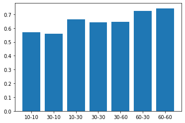

```python
max_val_acc = [max(log2.history['val_acc']), max(log2_1.history['val_acc']), max(log2_2.history['val_acc']),
               max(log2_3.history['val_acc']), max(log2_4.history['val_acc']), max(log2_5.history['val_acc']), max(log2_6.history['val_acc'])]
pl.bar(["10-10", "30-10", "10-30", "30-30", "30-60", "60-30", "60-60"], max_val_acc);
```

In terms of testing accuracy, SEQ_LEN = 60 and N_FUTURE = 60 produces the best results.

Furthermore, we observe that the model is overfitting even with Dropout layers. We suppose the reason is due to the nature of the stock market: "Past data cannot accurately predict future data."

Nonetheless, we see some promising results with these high test accuracies at certain epochs.

Different sequence lengths can represent different trends and technical patterns in the stock price. Thus, we decide to make a model with multiple inputs corresponding to sequences with different lengths. We fix the N_FUTURE parameter to 60, and vary the SEQ_LEN between 10, 20, and 30.

## Multi Input model

```python
SEQS_LEN = [10, 20, 30]        # Previous 10, 20, 30 days
N_FUTURE = 60                  # Next 60 days
SPLIT = 0.2
```

```python
train_data, test_data = [[] for _ in range(len(SEQS_LEN) + 1)], [[] for _ in range(len(SEQS_LEN) + 1)]

for ticker in data.columns:
    prices = data[ticker].values
    seqs = [[] for _ in range(len(SEQS_LEN) + 1)]   # +1 for labels

    for i in range(max(SEQS_LEN), len(prices)-N_FUTURE):     # Starting from the largest sequence length size

        # We want to compute the price direction from the current index.
        future_price_avg = np.mean(prices[i:i+N_FUTURE])
        # direction is 0 (negative) if the future price average is below the current price, otherwise direction is 1 (positive)
        price_dir = 0 if future_price_avg < prices[i] else 1

        for j in range(len(SEQS_LEN)):          # For each sequence size
            seqs[j].append( prices[i - SEQS_LEN[j] : i] )

        seqs[-1].append(price_dir)      # append labels

    for j in range(len(train_data)):
        split_index = int(len(seqs[j]) * (1 - SPLIT))
        train_data[j].extend(np.array(seqs[j])[:split_index])
        # We ignore the overlap of sequences between the train data and the test data
        test_data[j].extend(np.array(seqs[j])[split_index + max(SEQS_LEN):])
```

```python
np.random.seed(0)

indices = np.arange(len(train_data[0]))
np.random.shuffle(indices)
for j in range(len(train_data)):
    train_data[j] = np.array(train_data[j])[indices]

indices = np.arange(len(test_data[0]))
np.random.shuffle(indices)
for j in range(len(test_data)):
    test_data[j] = np.array(test_data[j])[indices]
```

```python
# Make sure the data shapes are fine
for j in range(len(test_data)):
    print(train_data[j].shape, test_data[j].shape)
```

```
(268256, 10) (42824, 10)
(268256, 20) (42824, 20)
(268256, 30) (42824, 30)
(268256,) (42824,)
```

### Model

```python
input1 = layers.Input(shape=(10,))
input2 = layers.Input(shape=(20,))
input3 = layers.Input(shape=(30,))

x = layers.Reshape((10, 1))(input1)
x = layers.LSTM(16)(x)
x = layers.Dense(16, activation="relu")(x)
x = layers.Dense(10, activation="relu")(x)
x = Model(inputs=input1, outputs=x)

y = layers.Reshape((20, 1))(input2)
y = layers.LSTM(32)(y)
y = layers.Dense(32, activation="relu")(y)
y = layers.Dense(10, activation="relu")(y)
y = Model(inputs=input2, outputs=y)

z = layers.Reshape((30, 1))(input3)
z = layers.LSTM(64)(z)
z = layers.Dense(64, activation="relu")(z)
z = layers.Dense(10, activation="relu")(z)
z = Model(inputs=input3, outputs=z)

combined = layers.concatenate([x.output, y.output, z.output])

c = layers.Dense(3, activation="relu")(combined)
c = layers.Dense(1, activation="sigmoid")(c)

model3 = Model(inputs=[x.input, y.input, z.input], outputs=c)
```

```python
model3.summary()
```

```
Model: "model_3"
__________________________________________________________________________________________________
Layer (type)                    Output Shape         Param #     Connected to
==================================================================================================
input_9 (InputLayer)            [(None, 10)]         0
__________________________________________________________________________________________________
input_10 (InputLayer)           [(None, 20)]         0
__________________________________________________________________________________________________
input_11 (InputLayer)           [(None, 30)]         0
__________________________________________________________________________________________________
reshape_7 (Reshape)             (None, 10, 1)        0           input_9[0][0]
__________________________________________________________________________________________________
reshape_8 (Reshape)             (None, 20, 1)        0           input_10[0][0]
__________________________________________________________________________________________________
reshape_9 (Reshape)             (None, 30, 1)        0           input_11[0][0]
__________________________________________________________________________________________________
lstm_14 (LSTM)                  (None, 16)           1152        reshape_7[0][0]
__________________________________________________________________________________________________
lstm_15 (LSTM)                  (None, 32)           4352        reshape_8[0][0]
__________________________________________________________________________________________________
lstm_16 (LSTM)                  (None, 64)           16896       reshape_9[0][0]
__________________________________________________________________________________________________
dense_20 (Dense)                (None, 16)           272         lstm_14[0][0]
__________________________________________________________________________________________________
dense_22 (Dense)                (None, 32)           1056        lstm_15[0][0]
__________________________________________________________________________________________________
dense_24 (Dense)                (None, 64)           4160        lstm_16[0][0]
__________________________________________________________________________________________________
dense_21 (Dense)                (None, 10)           170         dense_20[0][0]
__________________________________________________________________________________________________
dense_23 (Dense)                (None, 10)           330         dense_22[0][0]
__________________________________________________________________________________________________
dense_25 (Dense)                (None, 10)           650         dense_24[0][0]
__________________________________________________________________________________________________
concatenate (Concatenate)       (None, 30)           0           dense_21[0][0]
                                                                 dense_23[0][0]
                                                                 dense_25[0][0]
__________________________________________________________________________________________________
dense_26 (Dense)                (None, 3)            93          concatenate[0][0]
__________________________________________________________________________________________________
dense_27 (Dense)                (None, 1)            4           dense_26[0][0]
==================================================================================================
Total params: 29,135
Trainable params: 29,135
Non-trainable params: 0
__________________________________________________________________________________________________
```

```python
model3.compile(optimizer='adam', loss='binary_crossentropy', metrics=['acc'])
log3 = model3.fit(train_data[:-1], train_data[-1], validation_data=(test_data[:-1], test_data[-1]), epochs=50, batch_size=64)
```

```
Best test acc: 0.6650710105895996
```

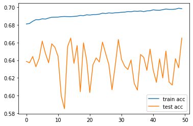

```python
pl.plot(log3.history['acc'])
pl.plot(log3.history['val_acc'])
pl.legend(['train acc', "test acc"])
print(f"Best test acc: {max(log3.history['val_acc'])}")
```

We observe that the multi sequence model does not solve the overfitting problem.

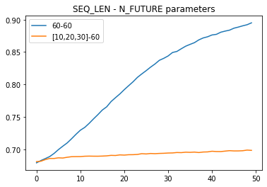

```python
pl.plot(log2_6.history['acc'])
pl.plot(log3.history['acc'])
pl.legend(["60-60", "[10,20,30]-60"])
pl.title("SEQ_LEN - N_FUTURE parameters");
```

In terms of training accuracy, when comparing the best parameters (SEQ_LEN=60, N_FUTURE=60) found earlier against the multi sequence model, we observe that the simple sequence model with one input performs significantly better (it converges faster over epochs).

```
[0.7437390685081482, 0.6650710105895996]
```

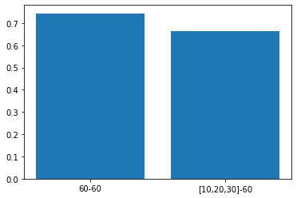

```python
max_val_acc = [max(log2_6.history['val_acc']), max(log3.history['val_acc'])]
pl.bar(["60-60", "[10,20,30]-60"], max_val_acc);
print([max(log2_6.history['val_acc']), max(log3.history['val_acc'])])
```

In terms of test accuracy, when comparing the best parameters (SEQ_LEN=60, N_FUTURE=60) found earlier against the multi sequence model, we observe that the simple model outperforms once again the multi sequence model by a significant margin.